# Sequenza pipeline

WU Fengyuan[^1]

2021/8/30

## Overview

Sequenza is a tool to analyze genomic sequencing data from paired normal-tumor samples, including cellularity and ploidy estimation; mutation and copy number (allele-specific and total copy number) detection, quantification and visualization.  
There are two parts of sequenza, seperately run in python and R. Sequenza also requires samtools and tabix available in the environment.

## Pipeline

**1.Input files**

| Files | Description |
| --- | --- |
| test_tumor.bam | Tumor sample bam file generated by BWA and filtered by GATK toolkit |
| test_normal.bam | Normal sample bam file generated by BWA and filtered by GATK toolkit. |
| reference.fasta | Refernce genome, take care of version like hg38 or hg19 |

**2.Produce a GC Wiggle track file**

```r
sequenza−utils gc_wiggle \
  −w 50 \
  --fasta reference.fasta \
  -o ref.gc50Base.wig.gz
```

**3.Process BAM and Wiggle files to produce a seqz file**

```r
sequenza−utils bam2seqz \
  -n normal.bam \
  -t tumor.bam \
  --fasta reference.fasta \
  -gc ref.gc50Base.wig.gz \
  -o out.seqz.gz
```

**Optional: Parallelization**

Run sequenza on multiple chromosomes at the same time, then merge the output files.

```r
chr=(chr1 chr2 chr3 chr4 chr5 chr6 chr7 chr8 chr9 chr10 chr11 chr12 chr13 chr14 chr15 chr16 chr17 chr18 chr19 chr20 chr21 chr22 chrX chrY)

sequenza-utils bam2seqz \
  --fasta reference.fasta \
  -n tumor.bam \
  -t normal.bam \
  -gc ref.gc50Base.wig.gz \
  -o out.seqz.gz \
  --parallel 10 \
  --chromosome ${chr[*]}

seqz=`for chr in ${chr[*]};do printf "out_${chr}.seqz.gz ";done`
zcat $seqz|gawk '{if (NR!=1 && $1 != "chromosome") {print $0}}'|bgzip >out.seqz.gz
```

**4.Post-process by binning the original seqz file**

```r
sequenza−utils seqz_binning --seqz out.seqz.gz -w 50 -o out small.seqz.gz
```

**5.Sequenza analysis (in R)**

```r
library(sequenza)

##sequenza.extract: process seqz data, normalization and segmentation
res=sequenza.extract("small.seqz.gz",verbose=FALSE,parallel=10)

##sequenza.fit: run grid-search approach to estimate cellularity and ploidy
cp=sequenza.fit(res)

##sequenza.results: write files and plots using suggested or selected solution
sequenza.results(sequenza.extract=res,cp.table=cp,sample.id=test,out.dir="result")
```

## Results

**1.seqz file**

| Column | Description |
| --- | --- |
| chromosome | Chromosome name |
| position | Base position |
| base.ref | Base in the reference genome |
| depth.normal | Read depth in the normal sample |
| depth.tumor | Read depth in the tumor sample |
| depth.ratio | Ratio of depth.tumor and depth.normal |
| Af | A-allele frequency in the tumor sample |
| Bf | B-allele frequency in the tumor sample, in heterozygous positions only |
| zygosity.nomal | Zygosity of the normal sample: “hom” for homozygous or “het” for heterozygous |
| GC.percent | % GC content |
| good.reads | Number of reads from the tumor sample which pass the quality threshold |
| AB.normal | Base(s) found in the normal sample, sorted by allele frequency if more than one |
| AB.tumor | Base(s) found in the tumor sample but not in the normal specimen, with their observed frequencies, separated by colons |
| tumor.strand | Identical to AB.tumor but indicating, for each variant base, the fraction of reads oriented in the forward direction |

**2.gc_plots.pdf**

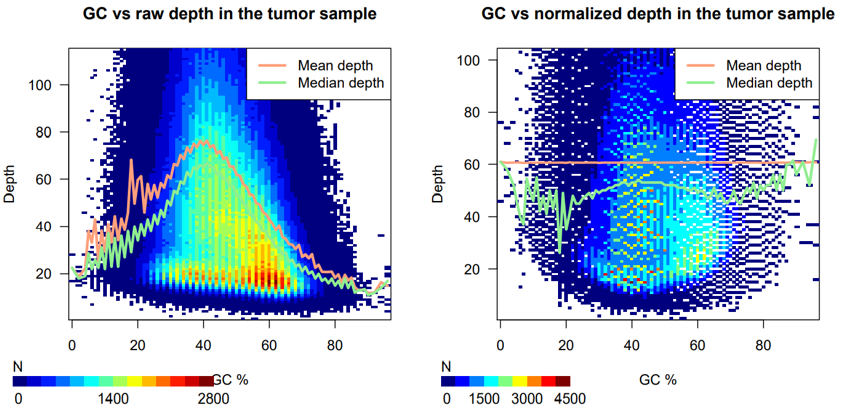

**3.CP_contours.pdf**

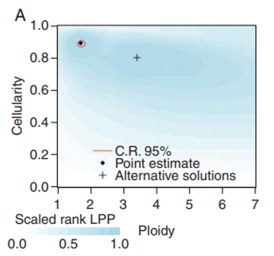

LPP:log posterior probability  
Point estimate and its confidence region for ploidy and cellularity. The point estimate is the ploidy and cellularity with maximum LPP. The 95% confidence region (C.R.95%) is the smallest (not necessarily contiguous) set of points with a total posterior probability >0.95.

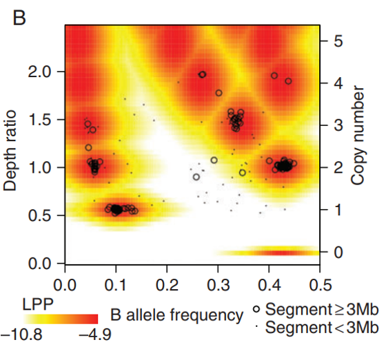

Copy number distribution of genomic regions.  
Black circles and dots: Observed depth ratio and BAF values for each genomic segment. The background color is the representative joint LPP density calculated for the cellularity and ploidy estimates identified in CP_contours.pdf

**5.chromosome_view.pdf**

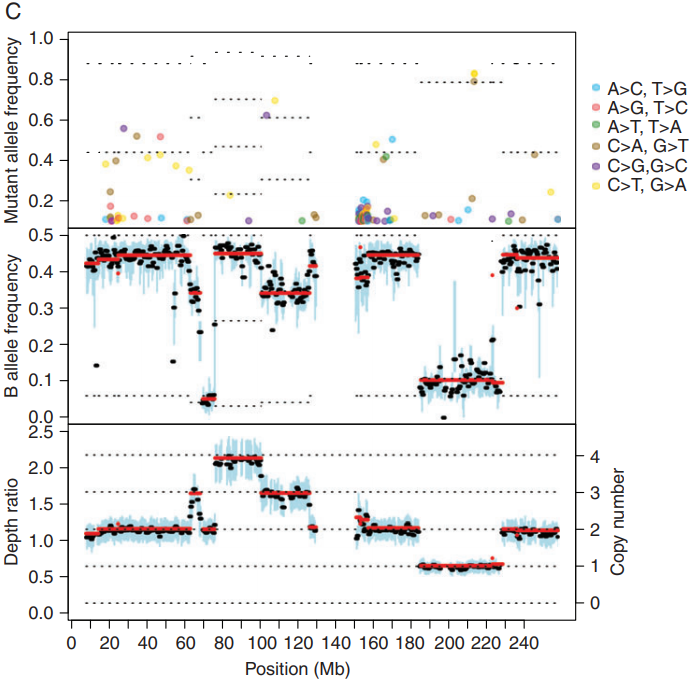

Chromosome plot indicating mutant allele frequency (top panel), B allele frequency (middle panel), and depth ratio (bottom panel).  
Black dots in the middle and bottom panels are actually short bars, represent 1 Mb sequence. Blue bar indicates the interquartile range. Red lines indicate segmented values. The thin dotted lines indicate the expectation values under the fitted model.

**6.genome_view.pdf**

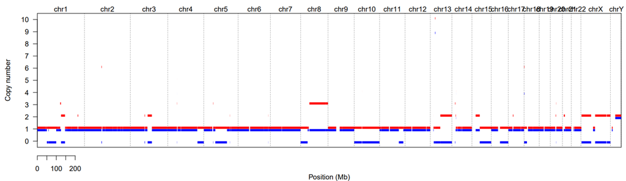

The copy number landscape of the whole genome.  
The red and blue bars are a pair of sister chromosomes.Related data is stored in segments.txt.

**7.segments.txt**

| Column | Description |
| --- | --- |
| chromosome | Chromosome |
| start.pos | Start position of the segment |
| end.pos | ENd position of the segment |
| Bf | B-allele frequency value |
| N.BAF | Number of observation to compute Bf in the segment |
| sd.BAF | Standard deviation of Bf |
| depth.ratio | Adjusted and normalized depth ratio tumor / normal |
| N.ratio | Number of observation to compute depth.ratio in the segment |
| sd.ratio | Standard deviation of depth.ratio |
| CNt | Estimated total copy number value |
| A | Estimated number of A-alleles |
| B | Estimated number of B-alleles (minor allele) |
| LPP | Log-posterior probability of the segment |

**8.Other files**

| File | Description |
| --- | --- |
| alternative_solutions.txt | List of all ploidy/cellularity alternative solution |
| CN_bars.pdf | Bar plot representing the percentage of genome in the detected copy number states |
| confints_CP.txt | Table of the confidence inerval of the best solution from the model |
| sequenza_cp_table.RData | RData object dump of the maxima a posteriori computation |
| sequenza_extract.RData | RData object dump of all the sample information |
| sequenza_log.txt | Log with version and time information |

[^1]: Institute of Zoology, CAS wufengyuan@ioz.ac.cn